# Water Quality Metric Data Analysis

### Visualization

The following are some facetted plots of variables of interest for quality standard. We are using the water quality measurement of **CCME WQI**, an its categories *Excellent* and *Poor** and the corresponding variable values that correspond to these.

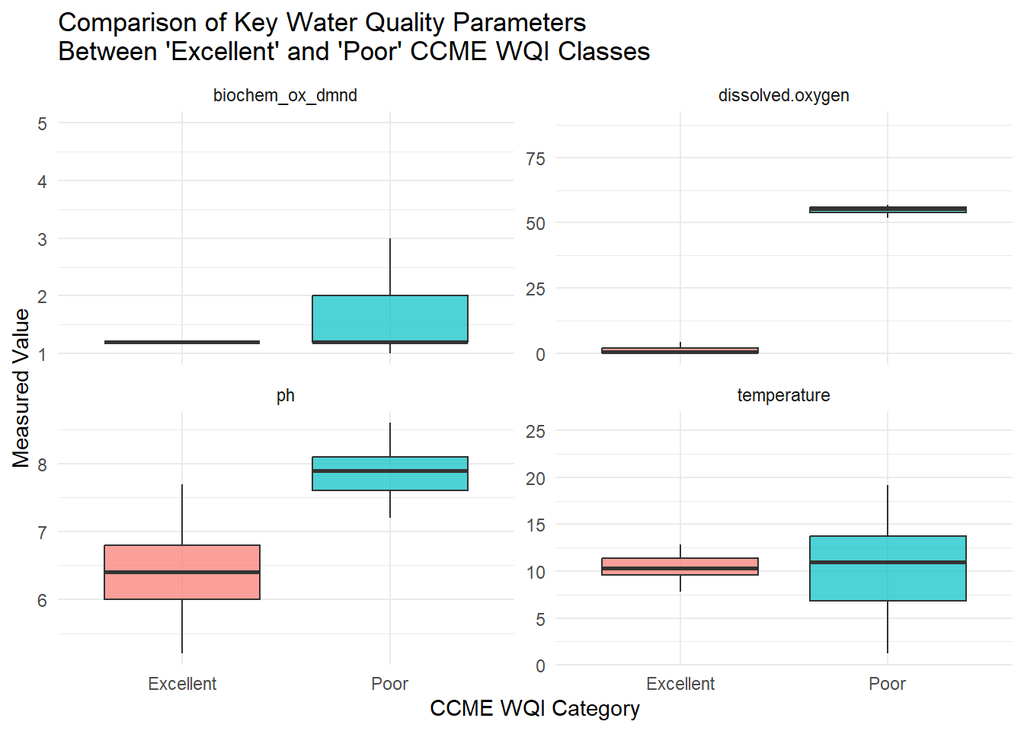

Figure 12: Boxplot of Water Quality variance per variable

```r
# keep onyl quality rows that contain v aleu of interest
wqi_long <- wqi_dsubset_clean_t_bod %>%
  tidyr::pivot_longer(
    cols = c(ph, temperature, biochem_ox_dmnd, dissolved.oxygen),
    names_to = "parameter",
    values_to = "value"
  )
wqi_subset <- wqi_long %>%
  filter(ccme_wqi %in% c("Excellent", "Poor"))

# boxplots for each parameter
ggplot(wqi_subset, aes(x = ccme_wqi, y = value, fill = ccme_wqi)) +
  geom_boxplot(alpha = 0.7, outlier.shape = NA) +
  facet_wrap(~ parameter, scales = "free_y", ncol = 2) +
  theme_minimal() +
  labs(
    title = "Comparison of Key Water Quality Parameters\nBetween 'Excellent' and 'Poor' CCME WQI Classes",
    x = "CCME WQI Category",
    y = "Measured Value"
  ) +
  theme(legend.position = "none")
```

Bocplots of water quality classification across variables - **bod**: Excellent Water Quality is achieved between 1-2.5 mg/L, not above this, but poor water quality can occur at any range of values. - **disolved oxygen**: Excellent water quality is achieved at narrow specific range of lower values while poor water quality is achieved at very narrow range of higher values circa 50+. - **ph**: Clear distinction between poor and excellent values.Higher ph values gviign pooer water quality. - **temperature**: There is a sweet spot between approx 9 and 12 where excellent quality occurs. Values higher (between approx 13C-18C) or lower (between approx 0C and 7C) lead to poorer water quality.

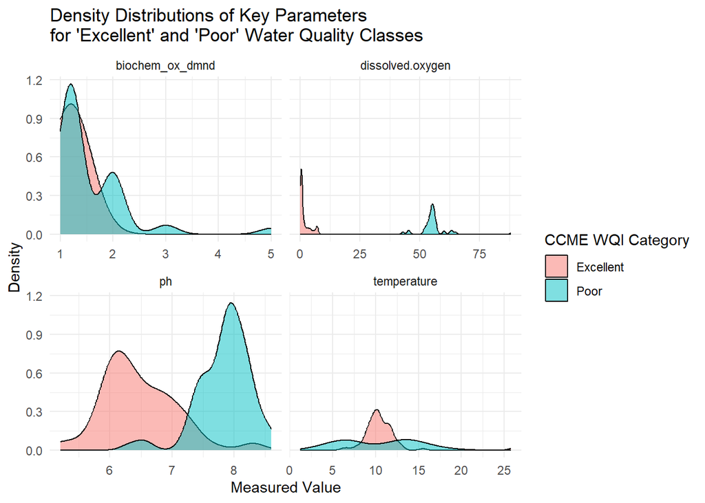

Figure 13: Water Quality variance per variable

```r
# create  facetted plot of excellent and poor for our data types t
# pipe the data into long format fo plotting specifyign what variables to sue
# and store in wqi_long dataframe
wqi_long <- wqi_dsubset_clean_t_bod %>%
  tidyr::pivot_longer(
    cols = c(ph, temperature, biochem_ox_dmnd, dissolved.oxygen),
    names_to = "parameter",
    values_to = "value"
  )

# keep onyl quality rows that contain v aleu of interest
wqi_subset <- wqi_long %>%
  filter(ccme_wqi %in% c("Excellent", "Poor"))

# create the facetted plot, set transparency to 0.5
ggplot(wqi_subset, aes(x = value, fill = ccme_wqi)) +
  geom_density(alpha = 0.5) +
  facet_wrap(~ parameter, scales = "free_x", ncol = 2) +
  theme_minimal() +
  labs(
    title = "Density Distributions of Key Parameters\nfor 'Excellent' and 'Poor' Water Quality Classes",
    x = "Measured Value",
    y = "Density",
    fill = "CCME WQI Category"
  )
```

“Density plots highlight differences in distribution shape between water quality classes. - **bod**: Excellent Water Quality is achieved between 1-2.5 mg/L, not above this, but poor water quality can occur at any range of values. - **disolved oxygen**: Excellent water quality is achieved at lower values while poor water quality is achieved at hgher values circa 50+. This pattern is contrary to the expected ecological relationship between DO and water quality, where higher oxygen typically indicates better conditions. The reversal may reflect dataset-specific factors such as differences between coastal or marine sampling locations, possible sensor calibration differences, or the weighting of dissolved oxygen within the CCME WQI calculation. This variable has also been classied as multimodal earlier. This would require further investigation. - **ph**: We see that the higher the ph value the poorer the water quality. - **temperature**: There is a sweet spot between approx 9 and 12 where excellent quality occurs. Values higher (between approx 13C-18C) or lower (between approx 0C and 7C) lead to poorer water quality

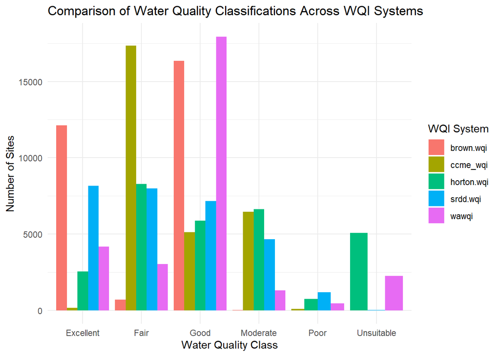

Figure 14: Comparative of numebr of variable values for water Quality Index systems

```r
# Select the relevant columns using the exact names you showed
wqi_compare <- wqi_dsubset_clean_t_bod %>%
  select(waterbodyname, ccme_wqi, wawqi, horton.wqi, brown.wqi, srdd.wqi) %>%
  pivot_longer(
    cols = -waterbodyname,
    names_to = "WQI_System",
    values_to = "Class"
  )

# Plot a comparison of classification counts
ggplot(wqi_compare, aes(x = Class, fill = WQI_System)) +
  geom_bar(position = "dodge") +
  theme_minimal() +
  labs(
    title = "Comparison of Water Quality Classifications Across WQI Systems",
    x = "Water Quality Class",
    y = "Number of Sites",
    fill = "WQI System"
  )
```

Below is a table of classification systems and how the same data for oru dataset is classified across each of them.

| Observation | Interpretation |
| --- | --- |
| **CCME_WQI** | Most values classified as **“Fair”**, very few reach the criteria **Excellent**. |
| **WAWQI** | Most values classified as**“Good”** and even spread for others. |
| **Brown_WQI** | Most values classified as**“Good”** and then **Excellent**. |
| **Horton_WQI** | Fairly even classification |
| **SRDD_WQI** | Even distributi acrss top 3 to 4 categories |

There is a large variety of standards. We will continue to use **CCME_WQI**, however using Fair as a more appropriate category for good water quality rather than excellent. as it appears to be very difficul to achieve that standard for Irish waters. This would require further investigation.

## Section 4 : Results

### Section 4.1 Hypothesis 1:

**Null and Alternate Hypothesis** Ho = There is no statistically significant relationship between Biochemical Oxygen Demand (BOD) and temperature Ha = There is a statistically significant elatinoshipt between Biochemical Oxygen Demand (BOD) and temperature

This is a two tailed test, as we do not indicate if is a positive or negative relationship.

**Variables**: - Biochemical Oxygen Demand (BOD): Variable is Continuous (ratio), and as per earlier analysis, its data can be considered to approximate a normal distribution. - temperature: Variable is Continous (interval), and as per earlier analysis, data can be considered to approximate a normal distribution.

**Statistical test**: Both variables are continuous ratio variable types. As such we will sue a *Pearson correlation* as our statistical test.

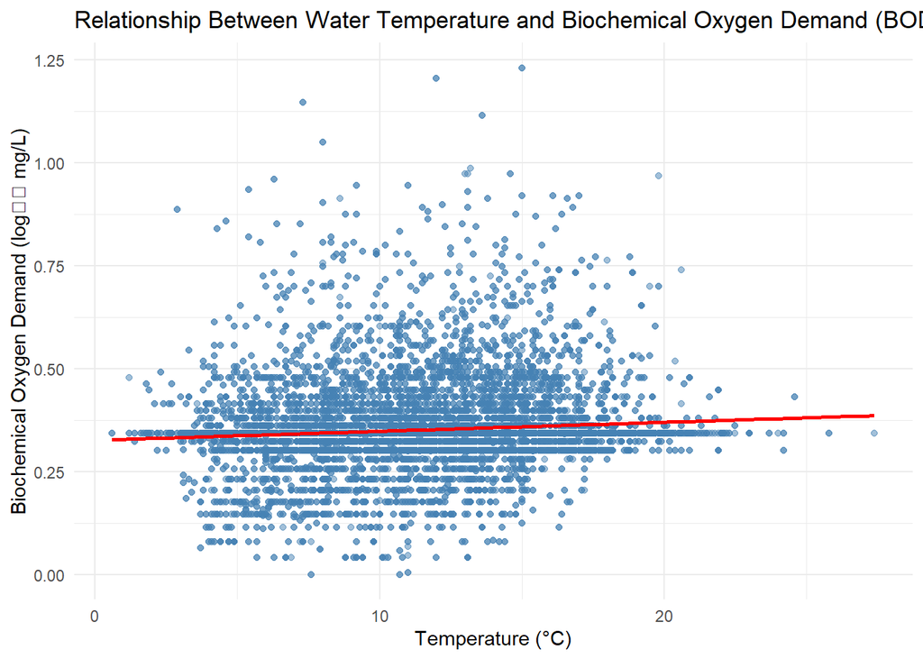

```r
#| label: scatter_temp_bod
#| fig.cap: "Figure 15: Scatterplot of Temperature and Biochemical Oxygen Demand (BOD)"
#| fig.align: center

ggplot(wqi_dsubset_clean_t_bod, aes(x = temperature, y = bod_log10)) +
  geom_point(alpha = 0.5, colour = "steelblue") +
  geom_smooth(method = "lm", colour = "red", se = FALSE) +
  labs(
    title = "Relationship Between Water Temperature and Biochemical Oxygen Demand (BOD)",
    x = "Temperature (°C)",
    y = "Biochemical Oxygen Demand (log₁₀ mg/L)"
  ) +
  theme_minimal()
```

Checking for *Homoscedasticity* and *Heterocedasciticity*. Scatterplot is not exact rectangle or square, but it is not a cone shape, as such we have Homoscedasticity.

Theer is also a very weak linear relationship.

```r
#| label: corr_bod_temp
#| fig.cap: "Table 12: Pearson Correlation Between Water Temperature and Biochemical Oxygen Demand (BOD)"

# Pearson correlation between Temperature and BOD (log10)
pearcor_bod_temp <- stats::cor.test(wqi_dsubset_clean_t_bod$temperature, wqi_dsubset_clean_t_bod$bod_log10, method = "pearson")

pearcor_bod_temp
```

```
    Pearson's product-moment correlation

data:  wqi_dsubset_clean_t_bod$temperature and wqi_dsubset_clean_t_bod$bod_log10
t = 17.937, df = 29152, p-value < 2.2e-16
alternative hypothesis: true correlation is not equal to 0
95 percent confidence interval:
 0.09311464 0.11582196
sample estimates:
      cor
0.1044819
```

```r
# calculate effect size Using function from effectsize package to convert t to Cohen's d

effectsize::t_to_d(t = pearcor_bod_temp$statistic, pearcor_bod_temp$parameter)
```

```
d    |       95% CI
-------------------
0.21 | [0.19, 0.23]
```

**Conclusion** While temperature has a bearing on BOD, it is a very weak affect and there must be another variable which drives the BOD value. Further anlysis will be required to identify that or those variables.

### Section 4.2 Hypothesis 2 :

**Null and Alternate Hypothesis** Ho = There is no statistically significant difference in mean ph between water bodies rated “Fair” and those rated “Poor” in the CCME_WQI water classification system. Ha = There is a statistically significant difference in mean pH between water bodies rated “Fair” and those rated “Poor” in the CCME_WQI water classification system.

This will be a two-tailed test as we are nto sayign it is greater or less than. We specify with alpha = 0.05.

**Variables**: - ph: Variable is Continuous (interval), and as per earlier analysis, its data can be considered to approximate a normal distribution. - ccme_wqi : Variable is Categorical(ordinal), and as per earlier analysis, data can be considered to approximate a normal distribution.

**Statistical test**: As one variable is Continuous(Interval) and the other is Categorical (Oordinal) with two factors, “Fair” and “Poor”. As such we will use an **Independent samples t-test** as our statistical test.

```r
# we'll create a new dataset, a subset fo our existing dataset with just the two factors
# we are interested in Fair and Poor
wqi_h2_subset <- wqi_dsubset_clean_t_bod %>%
  filter(ccme_wqi %in% c("Fair", "Poor")) %>%
  # drop the other levels in thr factor
  droplevels()


str(wqi_h2_subset)
```

```
'data.frame':   17432 obs. of  15 variables:
 $ waterbodyname   : chr  "Allua" "Allua" "Allua" "Allua" ...
 $ years           : int  2007 2007 2007 2007 2007 2007 2008 2008 2008 2008 ...
 $ month           : chr  "Aug" "Aug" "Aug" "Sep" ...
 $ alkalinity      : num  14 17 18 19 19 18 8 9 10 15 ...
 $ biochem_ox_dmnd : num  1.2 1.2 1.2 1.2 1.2 1.2 1.2 1.2 1.2 1.4 ...
 $ conductivity    : num  71 79 78 76 81 81 69 77 84 106 ...
 $ dissolved.oxygen: num  61.9 61.8 62.4 66 66 ...
 $ ph              : num  7.42 7.67 7.63 7.33 7.39 8.1 6.89 6.89 7.06 7.18 ...
 $ temperature     : num  17.8 18.1 17.8 20.1 20.5 20.8 8.9 9.7 9.5 6.6 ...
 $ ccme_wqi        : chr  "Fair" "Fair" "Fair" "Fair" ...
 $ wawqi           : chr  "Good" "Good" "Good" "Good" ...
 $ horton.wqi      : chr  "Moderate" "Moderate" "Moderate" "Moderate" ...
 $ brown.wqi       : chr  "Excellent" "Excellent" "Excellent" "Excellent" ...
 $ srdd.wqi        : chr  "Excellent" "Excellent" "Excellent" "Excellent" ...
 $ bod_log10       : num  0.342 0.342 0.342 0.342 0.342 ...
```

```r
nrow(wqi_h2_subset)
```

```
[1] 17432
```

```r
ncol(wqi_h2_subset)
```

```
[1] 15
```

**Density histogram plot**

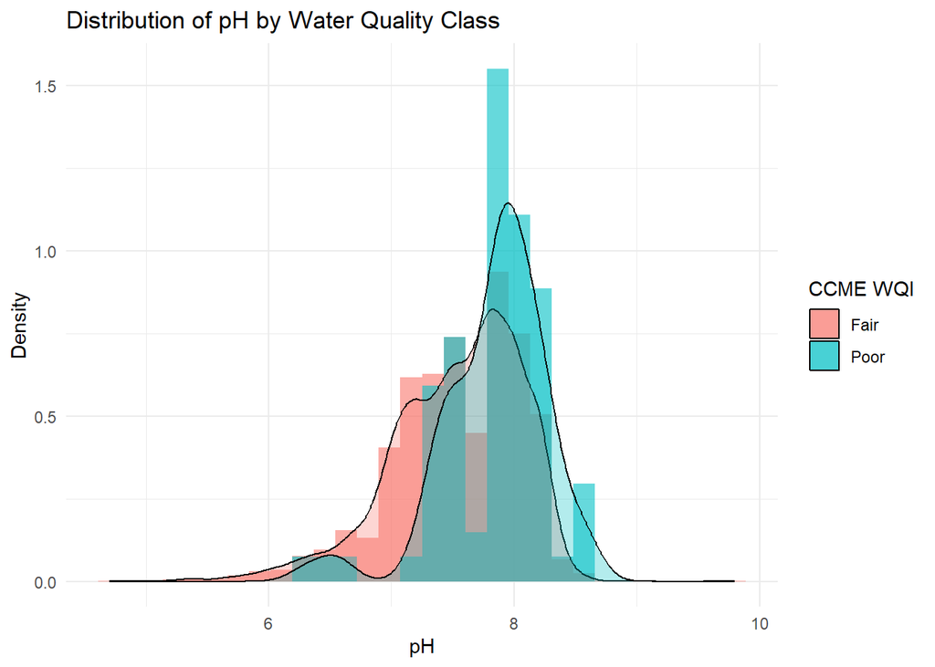

```r
ggplot(wqi_h2_subset, aes(x = ph, fill = ccme_wqi)) +
  geom_histogram(aes(y = ..density..), alpha = 0.6, position = "identity", bins = 30) +
  geom_density(alpha = 0.3) +
  theme_minimal() +
  labs(title = "Distribution of pH by Water Quality Class",
       x = "pH", y = "Density", fill = "CCME WQI")
```

**Box Plot**:

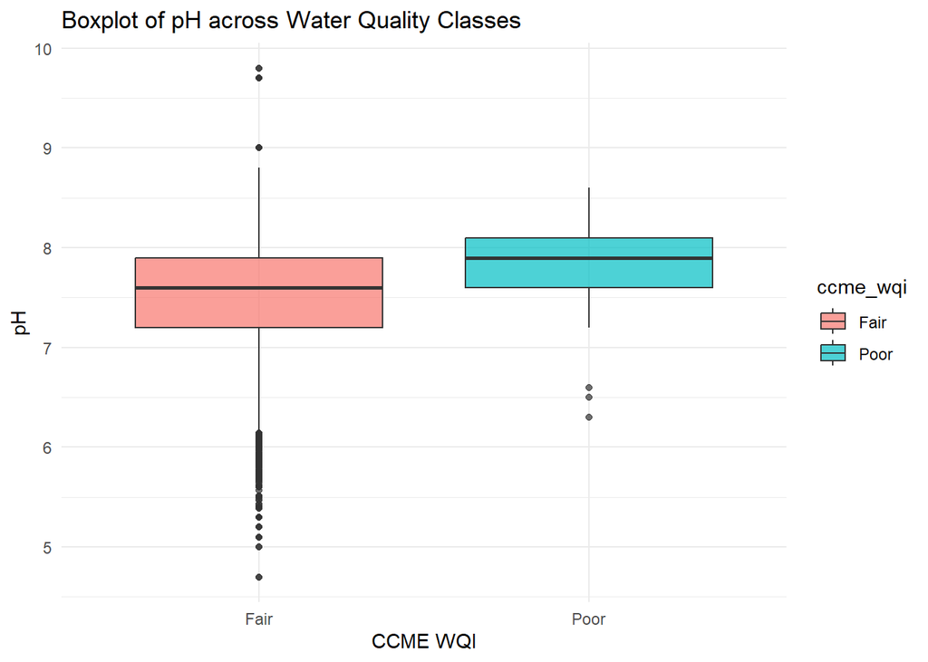

```r
ggplot(wqi_h2_subset, aes(x = ccme_wqi, y = ph, fill = ccme_wqi)) +
  geom_boxplot(alpha = 0.7) +
  theme_minimal() +
  labs(title = "Boxplot of pH across Water Quality Classes",
       x = "CCME WQI", y = "pH")
```

**Scatter Plot**

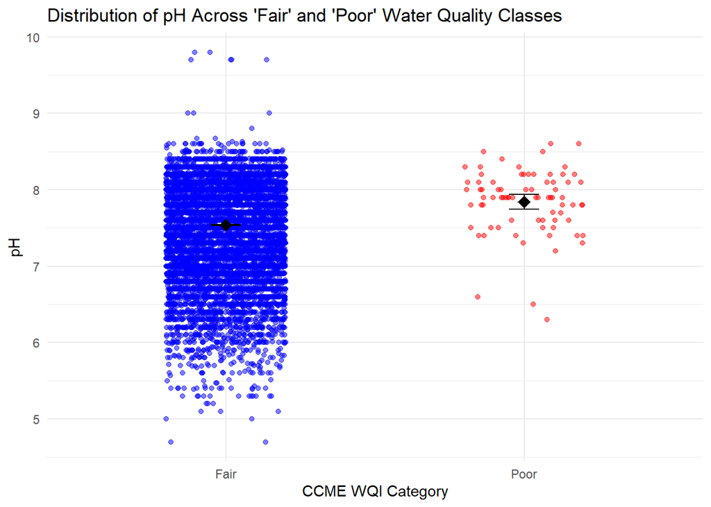

```r
#| label: scatter_ph_fair_poor
#| fig.cap: "Figure 16: Scatterplot of ph vs Fair and Poor Water Quality Categories"
#| fig.align: center


# Create scatter (jittered) plot
ggplot(wqi_h2_subset , aes(x = ccme_wqi, y = ph, colour = ccme_wqi)) +
  geom_jitter(width = 0.2, alpha = 0.5, size = 1.5) +
  stat_summary(fun = mean, geom = "point", shape = 18, size = 4, colour = "black") +
  stat_summary(fun.data = mean_cl_normal, geom = "errorbar", width = 0.1, colour = "black") +
  labs(
    title = "Distribution of pH Across 'Fair' and 'Poor' Water Quality Classes",
    x = "CCME WQI Category",
    y = "pH"
  ) +
 # scale_colour_manual(values = c("Fair" = "#1E90FF", "Poor" = "#FF4500")) +
  scale_colour_manual(values = c("Fair" = "blue", "Poor" = "red")) +
  theme_minimal() +
  theme(legend.position = "none")
```

rom the scatter plot we see ‘Fair’ has a comparatively large number of ph values witha spread from approx 5-9.5. Wheres ‘Poor’ has a smaller number of values in the range of approximately (6-8.5)

The means are approx 7.5 for ‘Fair’ and 7.9 for ‘Poor’

**Leven’s Test**:

```r
leveneTest(ph~ ccme_wqi, data=wqi_h2_subset)
```

```
Levene's Test for Homogeneity of Variance (center = median)
         Df F value   Pr(>F)
group     1  9.7235 0.001822 **
      17430
---
Signif. codes:  0 '***' 0.001 '**' 0.01 '*' 0.05 '.' 0.1 ' ' 1
```

Levene’s Test for testing equality of variances was run. the results were (F-statistic=9.72 and p=0.0018, df=1, 17430). As p< 0.05, this is a statistically sgnificant result.

The null hypothesis for Levene’s test is that variances are equal. Levene’s test for equality of variances was statistically significant, indicating that the assumption of homogeneity of variance does not hold.

As a resutl we will sue Welchs correction when running our independent t-test.

**Independent t-test**

We will use Welches correct when runnign thr t-test

```r
# where y is numeric and x is a binary factor
# var.equal  = False  as Welches correction is present as an outcome of the earlier
# leven's test i.e. we do not have homogeneity
res<-t.test(ph~ccme_wqi, data=wqi_h2_subset, var.equal = FALSE)
res
```

```
    Welch Two Sample t-test

data:  ph by ccme_wqi
t = -6.2791, df = 77.059, p-value = 1.854e-08
alternative hypothesis: true difference in means between group Fair and group Poor is not equal to 0
95 percent confidence interval:
 -0.4019413 -0.2083926
sample estimates:
mean in group Fair mean in group Poor
          7.536391           7.841558
```

```r
# #Calculate eta squared
# effes=round((res$statistic*res$statistic)/((res$statistic*res$statistic)+(res$parameter)),3)
# effes

effes <- round((6.2791^2) / ((6.2791^2) + res$parameter), 3)
effes
```

```
   df
0.338
```

**Results** Independetn t-test with Welch’s correction was run, the results being - t=-6.27 - df=77.059 - p-value = 1.854-08 , which we will report as < 0.01 - mean in group Fair = 7.536 - mean in group Poor - 7.841

Therefore, Poor has a higher mean ph value than Fair. The p-value is also very small, indicating it is a statistically signifcant result

he effect size value of eta squaed = 0.338, which indicates that 34% of the variance in ph can be attribute to differences between th Fair and Poor water quality classifications. This is a relatively large effect.

**Conclusion** A statistically significant result was found, therefore the Null hypothesis does not hold, and the alternate is true i.e. There is a statistically significant difference in mean pH between water bodies rated “Fair” and those rated “Poor” in the CCME_WQI water classification system.

The ph value accounts for approximately 34% of water quality rating variances between Fair and Poor quality classifications. This is a significant factor in water quality.

### Section 4.3 Hypothesis 3 :

Does Dissolved Oxygen (DO) differ significantly between Fair, Moderate, and Good water quality categories?

**Null and Alternate Hypothesis** Ho=There is no statistically significant difference in the median Dissolved Oxygen between the water quality categories. Ha = There is a statistically significant difference in median Dissolved Oxygen between at least two of the categories.

This will be a two-tailed test as we are not saying it is greater or less than. We specify with alpha = 0.05.

**Variables**: - dissolved.oxygen: Variable is Continuous (ratio), and as per earlier analysis, it cannot be considered normal, rather it is bimodal, and therefore non-parametric. - ccme_wqi : Variable is Categorical(ordinal), and as per earlier analysis, data can be considered to approximate a normal distribution. We are categorizing it into 3 categoriesm, “Fair”, “Moderate” and “Good”. We also confirmed earlier that aour categorical data is a factor with levels.

**Statistical test**: As one variable is Continuous (ratio) and the other is Categorical (Ordinal) with three factors, “Fair”, “Moderate” and “Good”. As such we will use an **Kruskal–Wallis** as our statistical test.

```r
# we'll create a new dataset, a subset fo our existing dataset with just the two factors
# we are interested in Fair and Poor
wqi_h3_subset <- wqi_dsubset_clean_t_bod %>%
  filter(ccme_wqi %in% c("Fair", "Moderate", "Good")) %>%
  # drop the other levels in thr factor
  droplevels()

# ensure the categories are levels in the factor
wqi_h3_subset$ccme_wqi <- factor(wqi_h3_subset$ccme_wqi, levels = c("Fair", "Moderate", "Good"))


str(wqi_h3_subset)
```

```
'data.frame':   28923 obs. of  15 variables:
 $ waterbodyname   : chr  "ABBEYTOWN_010" "Allua" "Allua" "Allua" ...
 $ years           : int  2023 2007 2007 2007 2007 2007 2007 2008 2008 2008 ...
 $ month           : chr  "Feb" "Aug" "Aug" "Aug" ...
 $ alkalinity      : num  314 14 17 18 19 19 18 8 9 10 ...
 $ biochem_ox_dmnd : num  1.2 1.2 1.2 1.2 1.2 1.2 1.2 1.2 1.2 1.2 ...
 $ conductivity    : num  711 71 79 78 76 81 81 69 77 84 ...
 $ dissolved.oxygen: num  52.5 61.9 61.8 62.4 66 ...
 $ ph              : num  7.8 7.42 7.67 7.63 7.33 7.39 8.1 6.89 6.89 7.06 ...
 $ temperature     : num  10.4 17.8 18.1 17.8 20.1 20.5 20.8 8.9 9.7 9.5 ...
 $ ccme_wqi        : Factor w/ 3 levels "Fair","Moderate",..: 2 1 1 1 1 1 1 1 1 1 ...
 $ wawqi           : chr  "Good" "Good" "Good" "Good" ...
 $ horton.wqi      : chr  "Unsuitable" "Moderate" "Moderate" "Moderate" ...
 $ brown.wqi       : chr  "Good" "Excellent" "Excellent" "Excellent" ...
 $ srdd.wqi        : chr  "Poor" "Excellent" "Excellent" "Excellent" ...
 $ bod_log10       : num  0.342 0.342 0.342 0.342 0.342 ...
```

```r
nrow(wqi_h3_subset)
```

```
[1] 28923
```

```r
ncol(wqi_h3_subset)
```

```
[1] 15
```

```r
table(wqi_h3_subset$ccme_wqi)
```

```
    Fair Moderate     Good
   17355     6451     5117
```

**Box Plot**

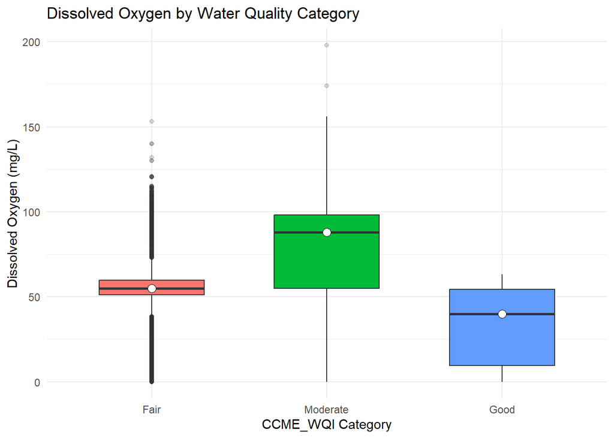

```r
ggplot(wqi_h3_subset, aes(x = ccme_wqi, y = dissolved.oxygen, fill = ccme_wqi)) +
  geom_boxplot(outlier.alpha = 0.2, width = 0.6) +
  stat_summary(fun = median, geom = "point", shape = 21, size = 3, fill = "white") +
  labs(
    title = "Dissolved Oxygen by Water Quality Category",
    x = "CCME_WQI Category",
    y = "Dissolved Oxygen (mg/L)"
  ) +
  theme_minimal() +
  theme(legend.position = "none")
```

```r
#run a kruskal wallis test - this is the omnibus stest
stats::kruskal.test(dissolved.oxygen~ccme_wqi,data=wqi_h3_subset)
```

```
    Kruskal-Wallis rank sum test

data:  dissolved.oxygen by ccme_wqi
Kruskal-Wallis chi-squared = 6479.2, df = 2, p-value < 2.2e-16
```

```r
# run the dunns test wuht bonnferroni correction
tmp <- FSA::dunnTest(dissolved.oxygen ~ ccme_wqi, data = wqi_h3_subset, method = "bonferroni")

#convert Dunn’s test result to a data frame
dunn_test_df <- as.data.frame(tmp$res)

#filter for statistically significant comparisons (p < 0.05)
significant_results <- dunn_test_df %>%
  filter(P.adj < 0.05)

# round the p-values for clarity
significant_results <- significant_results %>%
  mutate(
    P.unadj = round(P.unadj, 3),
    P.adj = round(P.adj, 3)
  )

#add median DO per group (for richer context)
group_medians <- wqi_h3_subset %>%
  group_by(ccme_wqi) %>%
  summarise(
    Median_DO = round(median(dissolved.oxygen, na.rm = TRUE), 2),
    IQR_DO = round(IQR(dissolved.oxygen, na.rm = TRUE), 2),
    n = n()
  )


ft <- flextable(significant_results) %>%
  set_table_properties(width = 1, layout = "autofit") %>%
  autofit()

#print results
ft
```

| Comparison | Z | P.unadj | P.adj |
| --- | --- | --- | --- |
| Fair - Good | 53.43153 | 0 | 0 |
| Fair - Moderate | -45.04225 | 0 | 0 |
| Good - Moderate | -80.48927 | 0 | 0 |

```r
group_medians
```

```
# A tibble: 3 × 4
  ccme_wqi Median_DO IQR_DO     n
  <fct>        <dbl>  <dbl> <int>
1 Fair          54.9   8.52 17355
2 Moderate      88    43.1   6451
3 Good          39.9  44.9   5117
```

**Result**

Therefore, this is statistically significant result, as p <0.01 which is a lot less than or critical value of 0.05.

The Kruskal-Wallis tells us there is a statistically significant result but it does not tell us which group it aplies to. We carry out Post hoc test to determine where the significant result ie.

Post hoc test was a Dunn’s test with a Bonnferoni correction. Kruskal–Wallis and Dunn’s tests confirm statistically that these medians differ significantly, but the direction is not what we might intuitively expect — “Good” water quality (per CCME_WQI) has the lowest median DO and largets spread (IQR - 44.9). he highest median being in thr Moderat Category, with IQR = 43.1)

there may be seasonal or possibly regional factors which could be affecting the result. This woudl require further investigation

**Conclusion**

The Kruskal–Wallis test (chi squared = 6479.2, df = 2, p < 0.001) indicated a significant difference in median dissolved oxygen across CCME_WQI categories. Dunn’s post hoc tests with Bonferroni correction, showed all pairwise differences were significant (p < 0.001). Median DO was highest for Moderate sites (88.0 mg/L), followed by Fair (54.9 mg/L), and lowest for Good (39.9 mg/L).

### Section 4.4 Hypothesis 4 :

Does water quality vary by month?

**Null and Alternate Hypothesis** Ho=There is no statistically significant association between Month and CCME_WQI classification. Ha = There is a statistically significant association between Month and CCME_WQI classification.

This will be a two-tailed test as we are not saying it is greater or less than. We specify with alpha = 0.05.

As we have more than two values in each category as will also use **Cramer’s V** to calculate the effect size if one exists.

```r
# we'll create a new dataset, a subset fo our existing dataset with just the two factors
# we are interested in Fair and Poor
wqi_h3_subset <- wqi_dsubset_clean_t_bod %>%
  filter(ccme_wqi %in% c("Fair", "Moderate", "Good")) %>%
  # drop the other levels in thr factor
  droplevels()

# ensure the categories are levels in the factor
wqi_h3_subset$ccme_wqi <- factor(wqi_h3_subset$ccme_wqi, levels = c("Fair", "Moderate", "Good"), ordered=FALSE)

# we'll make sure the  months are in calendar order and not alphabetical
# will eb easier for veiwing
wqi_h3_subset$month <- factor(
  wqi_h3_subset$month,
  levels = c("Jan","Feb","Mar","Apr","May","Jun",
             "Jul","Aug","Sep","Oct","Nov","Dec"),
  ordered = FALSE
)


str(wqi_h3_subset)
```

```
'data.frame':   28923 obs. of  15 variables:
 $ waterbodyname   : chr  "ABBEYTOWN_010" "Allua" "Allua" "Allua" ...
 $ years           : int  2023 2007 2007 2007 2007 2007 2007 2008 2008 2008 ...
 $ month           : Factor w/ 12 levels "Jan","Feb","Mar",..: 2 8 8 8 9 9 9 1 1 1 ...
 $ alkalinity      : num  314 14 17 18 19 19 18 8 9 10 ...
 $ biochem_ox_dmnd : num  1.2 1.2 1.2 1.2 1.2 1.2 1.2 1.2 1.2 1.2 ...
 $ conductivity    : num  711 71 79 78 76 81 81 69 77 84 ...
 $ dissolved.oxygen: num  52.5 61.9 61.8 62.4 66 ...
 $ ph              : num  7.8 7.42 7.67 7.63 7.33 7.39 8.1 6.89 6.89 7.06 ...
 $ temperature     : num  10.4 17.8 18.1 17.8 20.1 20.5 20.8 8.9 9.7 9.5 ...
 $ ccme_wqi        : Factor w/ 3 levels "Fair","Moderate",..: 2 1 1 1 1 1 1 1 1 1 ...
 $ wawqi           : chr  "Good" "Good" "Good" "Good" ...
 $ horton.wqi      : chr  "Unsuitable" "Moderate" "Moderate" "Moderate" ...
 $ brown.wqi       : chr  "Good" "Excellent" "Excellent" "Excellent" ...
 $ srdd.wqi        : chr  "Poor" "Excellent" "Excellent" "Excellent" ...
 $ bod_log10       : num  0.342 0.342 0.342 0.342 0.342 ...
```

```r
nrow(wqi_h3_subset)
```

```
[1] 28923
```

```r
ncol(wqi_h3_subset)
```

```
[1] 15
```

```r
table(wqi_h3_subset$ccme_wqi)
```

```
    Fair Moderate     Good
   17355     6451     5117
```

```r
table(wqi_h3_subset$month)
```

```
 Jan  Feb  Mar  Apr  May  Jun  Jul  Aug  Sep  Oct  Nov  Dec
1899 2827 2200 2736 2099 2767 2255 2167 2792 3072 2753 1356
```

**Contngency Table**

```r
# Create the contingency table (Month × Water Quality)
contingency_table <- table(wqi_h3_subset$month, wqi_h3_subset$ccme_wqi)

# Add row and column totals
contingency_with_totals <- addmargins(contingency_table)

# Display as a formatted table
knitr::kable(contingency_with_totals, digits = 0,
             caption = "Table 13: Contingency Table Month and Water Quality metric")
```

Table 13: Contingency Table Month and Water Quality metric

|  | Fair | Moderate | Good | Sum |
| --- | --- | --- | --- | --- |
| Jan | 1245 | 462 | 192 | 1899 |
| Feb | 1842 | 625 | 360 | 2827 |
| Mar | 1355 | 495 | 350 | 2200 |
| Apr | 1464 | 605 | 667 | 2736 |
| May | 1144 | 677 | 278 | 2099 |
| Jun | 1536 | 626 | 605 | 2767 |
| Jul | 1356 | 390 | 509 | 2255 |
| Aug | 1245 | 437 | 485 | 2167 |
| Sep | 1702 | 744 | 346 | 2792 |
| Oct | 1692 | 598 | 782 | 3072 |
| Nov | 1849 | 563 | 341 | 2753 |
| Dec | 925 | 229 | 202 | 1356 |
| Sum | 17355 | 6451 | 5117 | 28923 |

```r
#CrossTable(predictor, outcome, fisher = TRUE, chisq = TRUE, expected = TRUE)
#Note: for this approach there must be the same number of values for both variables so
#missing data is important.

# Remove rows where either variable is NA
wqi_clean <- wqi_h3_subset %>%
  filter(!is.na(month) & !is.na(ccme_wqi))

# Now run CrossTable requesting both Fisher and Chi Square so we have full information
# We request the format in SPSS to make it easier to interpret.
gmodels::CrossTable(
  wqi_clean$month,
  wqi_clean$ccme_wqi,
  fisher = FALSE,
  chisq = TRUE,
  expected = TRUE,
  sresid = TRUE,
  format = "SPSS"
)
```

```
   Cell Contents
|-------------------------|
|                   Count |
|         Expected Values |
| Chi-square contribution |
|             Row Percent |
|          Column Percent |
|           Total Percent |
|            Std Residual |
|-------------------------|

Total Observations in Table:  28923

                | wqi_clean$ccme_wqi
wqi_clean$month |     Fair  | Moderate  |     Good  | Row Total |
----------------|-----------|-----------|-----------|-----------|
            Jan |     1245  |      462  |      192  |     1899  |
                | 1139.479  |  423.554  |  335.967  |           |
                |    9.772  |    3.490  |   61.692  |           |
                |   65.561% |   24.329% |   10.111% |    6.566% |
                |    7.174% |    7.162% |    3.752% |           |
                |    4.305% |    1.597% |    0.664% |           |
                |    3.126  |    1.868  |   -7.854  |           |
----------------|-----------|-----------|-----------|-----------|
            Feb |     1842  |      625  |      360  |     2827  |
                | 1696.317  |  630.535  |  500.147  |           |
                |   12.511  |    0.049  |   39.271  |           |
                |   65.157% |   22.108% |   12.734% |    9.774% |
                |   10.614% |    9.688% |    7.035% |           |
                |    6.369% |    2.161% |    1.245% |           |
                |    3.537  |   -0.220  |   -6.267  |           |
----------------|-----------|-----------|-----------|-----------|
            Mar |     1355  |      495  |      350  |     2200  |
                | 1320.091  |  490.689  |  389.220  |           |
                |    0.923  |    0.038  |    3.952  |           |
                |   61.591% |   22.500% |   15.909% |    7.606% |
                |    7.808% |    7.673% |    6.840% |           |
                |    4.685% |    1.711% |    1.210% |           |
                |    0.961  |    0.195  |   -1.988  |           |
----------------|-----------|-----------|-----------|-----------|
```

[output cut: 72 more lines]

```
   Column Total |    17355  |     6451  |     5117  |    28923  |
                |   60.004% |   22.304% |   17.692% |           |
----------------|-----------|-----------|-----------|-----------|


Statistics for All Table Factors


Pearson's Chi-squared test
------------------------------------------------------------
Chi^2 =  780.6268     d.f. =  22     p =  7.155635e-151



       Minimum expected frequency: 239.9008
```

```r
#
# Create contingency table
mytable <- xtabs(~ month + ccme_wqi, data = wqi_clean)
#You can use the chisq.test function in the stats package to do the test
#set the flag correct=TRUE to get Yates correction needed for 2x2 table
ctest <- stats::chisq.test(mytable, correct = FALSE)
# No Yates correction (not 2x2)
ctest
```

```
    Pearson's Chi-squared test

data:  mytable
X-squared = 780.63, df = 22, p-value < 2.2e-16
```

```r
# Cramer's V (strength of association)
# effect_size <- sjstats::cramer(mytable)
# effect_size

# Optional: Phi coefficient (for 2x2 tables only)
#Calculate effect sizes
# sjstats::phi(mytable)
sjstats::cramer(mytable)
```

```
[1] 0.1161676
```

**Result**

There is a statistically significant association between Month and CCME_WQI classification (χ²(22, N = 28,923) = 780.63, p < 0.001).

A Chi-square test of independence found a statistically significant association result between month and CCME_WQI classification, chi squared (22, N = 28,923) = 780.63, p < .001.

Cramér’s V = 0.12 indicated a small effect size, suggesting that water quality classifications vary modestly across months.

“Good” classifications were more frequent in spring and autumn (April, October) and less frequent in winter (January–February), indicating seasonal variation in water quality.

Column totals on Right hand side collectively add up to 100% which is a good sign.

**Conclusion**

This indicates that water quality classifications vary significantly across months — suggesting a seasonal pattern in water quality levels. This requires further investigation.

## Appendix

### Dataset analysis

```r
head(wqi_df)
```

```
  waterbodyname years sampledate alkalinity.total..as.caco3.
1 ABBEYTOWN_010  2023        Feb                         314
2         Allua  2007        Aug                          14
3         Allua  2007        Aug                          17
4         Allua  2007        Aug                          18
5         Allua  2007        Sep                          19
6         Allua  2007        Sep                          19
  ammonia.total..as.n. bod...5.days..total. chloride conductivity..25.c
1                0.033                  1.2     27.3                711
2                0.033                  1.2     10.0                 71
3                0.033                  1.2     11.5                 79
4                0.033                  1.2     11.3                 78
5                0.033                  1.2     10.5                 76
6                0.066                  1.2     11.4                 81
  dissolved.oxygen ortho.phosphate..as.p....unspecified   ph temperature
```

[output cut: 20 more lines]

```r
nrow(wqi_df)
```

```
[1] 29159
```

```r
ncol(wqi_df)
```

```
[1] 24
```

```r
str(wqi_df)
```

```
'data.frame':   29159 obs. of  24 variables:
 $ waterbodyname                       : chr  "ABBEYTOWN_010" "Allua" "Allua" "Allua" ...
 $ years                               : int  2023 2007 2007 2007 2007 2007 2007 2008 2008 2008 ...
 $ sampledate                          : chr  "Feb" "Aug" "Aug" "Aug" ...
 $ alkalinity.total..as.caco3.         : num  314 14 17 18 19 19 18 8 9 10 ...
 $ ammonia.total..as.n.                : num  0.033 0.033 0.033 0.033 0.033 0.066 0.033 0.069 0.068 0.067 ...
 $ bod...5.days..total.                : num  1.2 1.2 1.2 1.2 1.2 1.2 1.2 1.2 1.2 1.2 ...
 $ chloride                            : num  27.3 10 11.5 11.3 10.5 11.4 11.6 13.2 14.8 15 ...
 $ conductivity..25.c                  : num  711 71 79 78 76 81 81 69 77 84 ...
 $ dissolved.oxygen                    : num  52.5 61.9 61.8 62.4 66 ...
 $ ortho.phosphate..as.p....unspecified: num  0.019 0.019 0.019 0.019 0.019 0.019 0.019 0.005 0.005 0.019 ...
 $ ph                                  : num  7.8 7.42 7.67 7.63 7.33 7.39 8.1 6.89 6.89 7.06 ...
 $ temperature                         : num  10.4 17.8 18.1 17.8 20.1 20.5 20.8 8.9 9.7 9.5 ...
 $ total.hardness..as.caco3.           : num  370 13.4 15.8 15.9 15.4 17.1 16.8 10.8 11.7 11 ...
 $ true.colour                         : num  24 35 29 31 23 26 25 33 28 31 ...
 $ ccme_values                         : num  64.1 76.8 77.2 77 76.9 ...
 $ ccme_wqi                            : chr  "Moderate" "Fair" "Fair" "Fair" ...
 $ wawqi_values                        : num  68.1 68.9 69 69 69.4 ...
 $ wawqi                               : chr  "Good" "Good" "Good" "Good" ...
 $ horton_values                       : num  117.6 33.8 35 35.2 36.3 ...
 $ horton.wqi                          : chr  "Unsuitable" "Moderate" "Moderate" "Moderate" ...
 $ brown_values                        : num  72.7 97.6 97.4 97.3 97.2 ...
 $ brown.wqi                           : chr  "Good" "Excellent" "Excellent" "Excellent" ...
 $ srdd_values                         : num  38.5 96.2 96 95.9 95.7 ...
 $ srdd.wqi                            : chr  "Poor" "Excellent" "Excellent" "Excellent" ...
```

### Missing Data:

There are no missing values. No placeholders which may indicate null data is presidential. As a result of no missing data being present there was no need to run Little’s test, to identify MCAR data, or dig subsequently into MAR or MNAR options. Thsi did not come into play as the data set was clean.

```r
# Missing Data
# carete a list of valeus that can be opresent in data, to ID them
placeholders <- c("?", "unknown", "none", "na", "n/a", "missing", "null", "NULL", "NaN", "-", "--", " ")

# check if placeholder list avlues above exist in the dataset
# convert all occurrences of the list elements in datframe to NA to standardise missing or misleadingg data values
# and allow yo deal wiht them together cleanly
# sourced from here https://www.rdocumentation.org/packages/naniar/versions/1.1.0/topics/replace_with_na_all
wqi_dsubset_clean <- replace_with_na_all(data = wqi_dsubset, condition = ~ tolower(as.character(.x)) %in% placeholders)


# get summary table of numebrs and percentages for missing non real values
missing_data_summary <- miss_var_summary(wqi_dsubset)

# View results
print(missing_data_summary)
```

```
# A tibble: 14 × 3
   variable         n_miss pct_miss
   <chr>             <int>    <num>
 1 waterbodyname         0        0
 2 years                 0        0
 3 month                 0        0
 4 alkalinity            0        0
 5 biochem_ox_dmnd       0        0
 6 conductivity          0        0
 7 dissolved.oxygen      0        0
 8 ph                    0        0
 9 temperature           0        0
10 ccme_wqi              0        0
11 wawqi                 0        0
12 horton.wqi            0        0
13 brown.wqi             0        0
14 srdd.wqi              0        0
```

### Future areas of study

- inlcude analysis on water body types i.e. rivers, lakes, etc
- extreme data values - sometimes hard to kno if they are error or real data. Need perisitence over time, persistence in location and measurement. Some more detailed geographical knowledge is could eb added ot the analysis perhaps..
- Water quality standards, **CCME_WQI** , **WAWQI** , | **Brown_WQI** ,| **Horton_WQI**, | **SRDD_WQI**. Sme additional analysis may be needed on them.

## References

- [EPA - Summary report - Water qaulity in ireland] (https://www.epa.ie/publications/monitoring–assessment/freshwater–marine/EPA-Water-Quality-in-Ireland-Summary-Report-ACC.pdf )
- Curran, West and Finch (1996).
- Field, Miles and Field (2012),
- knitr to create a table of values # details sbased around examples from here https://www.geeksforgeeks.org/r-language/kable-method-in-r/
- ggplot # create a histogram of ph with density curve over it # some referene taken from ehre https://stackoverflow.com/questions/5688082/overlay-histogram-with-density-curve
- Water quality standards, **CCME_WQI** , **WAWQI** , | **Brown_WQI** ,| **Horton_WQI**, | **SRDD_WQI**
- https://rstudio.github.io/cheatsheets/html/data-visualization.html